# personal-loan-logistic-regression-decision-tree

### Actionable Insights & Recommendations

### Misclassification Analysis

```python
misclass_df = X_test_dt.copy()
```

```python
misclass_df['Actual']=y_test_dt
misclass_df['Predicted'] = y_pred
```

[output not shown]

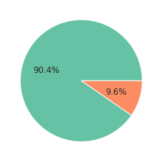

```python
plt.pie(data=misclass_df,x=misclass_df["Actual"].value_counts(),autopct='%1.1f%%')
```

[output not shown]

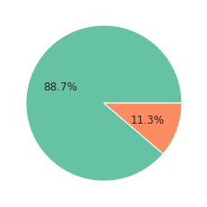

```python
plt.pie(data=misclass_df,x=misclass_df["Predicted"].value_counts(),autopct='%1.1f%%')
```

Percentage of value predicted by our model has been very close to the actual values. Lets find out False Negative and False Positive observations

```python
pd.crosstab(misclass_df['Predicted'],misclass_df['Actual'],margins=True)
```

| Actual Predicted | 0 | 1 | All |
| --- | --- | --- | --- |
| 0 | 1325 | 6 | 1331 |
| 1 | 31 | 138 | 169 |
| All | 1356 | 144 | 1500 |

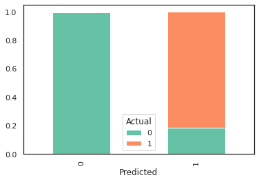

```python
pd.crosstab(misclass_df['Predicted'],misclass_df['Actual'],normalize='index').plot(kind='bar',stacked=True)
```

```python
# Rows that were classified as Negative when they were actually positive
fn_rows = misclass_df[(misclass_df['Actual'] == 1) & (misclass_df['Predicted'] == 0)]
```

```python
False_negative= df_Decision[df_Decision.index.isin(fn_rows.index.values)].copy()
False_negative
```

|  | Age | Income | Family | CCAvg | Education | Mortgage | PersonalLoan | SecuritiesAccount | CDAccount | Online | CreditCard | Regions |
| --- | --- | --- | --- | --- | --- | --- | --- | --- | --- | --- | --- | --- |
| 322 | 63 | 101 | 1 | 3.90 | 1 | 0 | 1 | 1 | 1 | 1 | 0 | Southern |
| 1069 | 44 | 75 | 2 | 3.50 | 1 | 0 | 1 | 0 | 0 | 1 | 0 | Los Angeles Region |
| 1518 | 43 | 64 | 4 | 3.00 | 3 | 221 | 1 | 0 | 0 | 1 | 0 | Bay Area |
| 2533 | 54 | 111 | 1 | 1.10 | 2 | 0 | 1 | 0 | 0 | 1 | 0 | Southern |
| 2623 | 42 | 111 | 3 | 3.00 | 1 | 0 | 1 | 1 | 1 | 0 | 1 | Bay Area |
| 2996 | 42 | 103 | 1 | 3.33 | 1 | 0 | 1 | 1 | 1 | 1 | 1 | Los Angeles Region |

```python
# Rows that were classified as postive when they were actually negative
fp_rows = misclass_df[(misclass_df['Actual'] == 0) & (misclass_df['Predicted'] == 1)]
fp_rows
False_Positive= df_Decision[df_Decision.index.isin(fp_rows.index.values)].copy()
False_Positive
```

|  | Age | Income | Family | CCAvg | Education | Mortgage | PersonalLoan | SecuritiesAccount | CDAccount | Online | CreditCard | Regions |
| --- | --- | --- | --- | --- | --- | --- | --- | --- | --- | --- | --- | --- |
| 10 | 65 | 105 | 4 | 2.40 | 3 | 0 | 0 | 0 | 0 | 0 | 0 | Bay Area |
| 82 | 41 | 82 | 1 | 4.00 | 3 | 0 | 0 | 0 | 0 | 1 | 0 | Southern |
| 185 | 39 | 115 | 1 | 1.00 | 3 | 0 | 0 | 0 | 0 | 1 | 0 | Southern |
| 621 | 41 | 114 | 2 | 1.80 | 2 | 0 | 0 | 0 | 0 | 1 | 0 | Los Angeles Region |
| 640 | 43 | 85 | 1 | 3.70 | 3 | 327 | 0 | 1 | 0 | 1 | 0 | Bay Area |
| 683 | 40 | 82 | 1 | 3.60 | 2 | 0 | 0 | 0 | 0 | 0 | 0 | Los Angeles Region |
| 731 | 28 | 90 | 2 | 3.30 | 1 | 0 | 0 | 0 | 0 | 1 | 1 | Los Angeles Region |
| 746 | 62 | 85 | 4 | 3.40 | 2 | 0 | 0 | 0 | 0 | 1 | 0 | Bay Area |
| 792 | 41 | 98 | 1 | 4.00 | 3 | 0 | 0 | 0 | 0 | 0 | 1 | Southern |
| 932 | 51 | 112 | 3 | 1.80 | 2 | 0 | 0 | 1 | 1 | 1 | 1 | Bay Area |
| 950 | 32 | 112 | 4 | 1.80 | 2 | 0 | 0 | 0 | 0 | 1 | 0 | Bay Area |
| 973 | 43 | 85 | 1 | 4.00 | 3 | 287 | 0 | 0 | 0 | 1 | 0 | Southern |
| 986 | 53 | 101 | 4 | 4.90 | 1 | 0 | 0 | 0 | 0 | 1 | 0 | Los Angeles Region |
| 1263 | 35 | 85 | 4 | 4.00 | 3 | 0 | 0 | 0 | 0 | 1 | 0 | Southern |
| 1303 | 29 | 112 | 2 | 2.00 | 2 | 382 | 0 | 1 | 0 | 0 | 0 | Bay Area |
| 1401 | 40 | 84 | 1 | 3.70 | 3 | 0 | 0 | 0 | 0 | 1 | 0 | Bay Area |
| 1910 | 43 | 83 | 2 | 3.80 | 3 | 112 | 0 | 0 | 0 | 0 | 0 | Central |
| 2437 | 65 | 114 | 4 | 3.40 | 2 | 0 | 0 | 0 | 0 | 0 | 1 | Bay Area |
| 3064 | 59 | 83 | 3 | 4.40 | 1 | 0 | 0 | 0 | 0 | 1 | 0 | Bay Area |
| 3081 | 36 | 78 | 2 | 4.50 | 3 | 204 | 0 | 0 | 0 | 1 | 1 | Bay Area |
| 3263 | 32 | 84 | 4 | 3.40 | 1 | 0 | 0 | 0 | 0 | 1 | 0 | Southern |
| 3322 | 41 | 104 | 1 | 4.00 | 3 | 0 | 0 | 0 | 1 | 1 | 1 | Southern |
| 3409 | 29 | 113 | 2 | 2.00 | 2 | 84 | 0 | 0 | 0 | 1 | 1 | Central |
| 3468 | 43 | 113 | 2 | 1.80 | 2 | 0 | 0 | 0 | 0 | 0 | 1 | Bay Area |
| 3754 | 63 | 112 | 4 | 2.40 | 3 | 0 | 0 | 0 | 0 | 1 | 1 | Southern |
| 4419 | 42 | 85 | 1 | 3.70 | 3 | 272 | 0 | 0 | 0 | 0 | 0 | Southern |
| 4492 | 56 | 91 | 1 | 3.00 | 3 | 0 | 0 | 0 | 0 | 1 | 1 | Bay Area |
| 4570 | 32 | 99 | 2 | 4.50 | 3 | 249 | 0 | 0 | 0 | 1 | 0 | Southern |
| 4671 | 39 | 104 | 1 | 4.00 | 3 | 0 | 0 | 0 | 1 | 1 | 1 | Bay Area |
| 4678 | 33 | 115 | 1 | 2.70 | 2 | 283 | 0 | 0 | 0 | 1 | 0 | Southern |
| 4815 | 58 | 99 | 2 | 1.40 | 1 | 0 | 0 | 0 | 0 | 0 | 1 | Southern |

On analyzing the Education , we can see most of them have education as Advance or Graduate . These cases are some exceptions.

### Recommendation

- Decision trees doesn't require to much data preparation or handling of outliers like logistic regression. They are easy to understand. Decision tress can easily overfit , so we have to be careful using decision tree.
- Based on EDA, logistic Regression , Decision tree , Income ,Educatoin,Family,CCavg are most important factor.
- Customers who have income above 98k dollars , Advance/graduate level education, a family of more than 2, such customers have higher chances of taking personal loans.
- So for this campaign we can have different profiles for customers.
- `High Profile Clients` :-Higher income,Advanced/Graduate level education, 3 /4 Family members,high spending
- `Average Profile` :- Medium income group,Graduate level education.3/4Family members,medium spending
- `Low Profile`:-Lower income group,undergrads ,3/4Family Member,low spending
- Customer Average Spending and Mortages can also be looked upon as based on EDA and logistic Regression this parameters also play some role in likelihood of buy loan.
- We can 1st target high profile customers , by providing them with a personal relationship managers who can address there concerns and can pursue them to buy loan from the bank with completive interest rates.
- Prequalifying for Loan can also attract more customers.
- Our 2nd target would be Medium profile customers.
- The model cannot identify well if there are some exceptional cases when low profile customer is ready to buy a personal loan.